# Clustering 3K PBMCs with Bioconductor

Author

Kevin Rue-Albrecht

*Generated: 2026-10-06 15:49:46*

## Context

This tutorial demonstrates a single-cell analysis workflow using Bioconductor packages, while discussing its implementation as a [Galaxy Training Network (GTN)](https://training.galaxyproject.org/) tutorial.

## Libraries

```r
library(cowplot)
library(DropletUtils)
library(LoomExperiment)
library(scrapper)
library(scater)
library(scuttle)
```

## Data

### Data download

To create a parallel tutorial to the existing tutorial [Clustering 3K PBMCs with Seurat](https://training.galaxyproject.org/training-material/topics/single-cell/tutorials/scrna-seurat-pbmc3k/tutorial.html), input data files were downloaded from these Zenodo links:

```
https://zenodo.org/record/3581213/files/genes.tsv
https://zenodo.org/record/3581213/files/barcodes.tsv
https://zenodo.org/record/3581213/files/matrix.mtx
```

```r
if (!dir.exists("data")) {
    dir.create("data")
}
if (!file.exists("data/genes.tsv")) {
    download.file("https://zenodo.org/record/3581213/files/genes.tsv", "data/genes.tsv")
}
if (!file.exists("data/barcodes.tsv")) {
    download.file("https://zenodo.org/record/3581213/files/barcodes.tsv", "data/barcodes.tsv")
}
if (!file.exists("data/matrix.mtx")) {
    download.file("https://zenodo.org/record/3581213/files/matrix.mtx", "data/matrix.mtx")
}
```

### Create a SingleCellExperiment Object

The common data structure adopted by Bioconductor packages to store the matrix as well as gene and cell annotations is called `SingleCellExperiment`.

We can import the matrix and annotations of genes and cells into an `SingleCellExperiment` object using the function `read10xCounts()` of the package [DropletUtils](https://bioconductor.org/packages/DropletUtils/).

We set the `samples=` argument to the directory that contains the three 10x files. Changing `row.names=` from the default `"id"` to `"symbol"` ensures that human-readable gene symbols are used instead of the database-friendlier Ensembl gene identifiers. Either way, both Ensembl gene identifiers and gene symbols will be stored in the `rowData()` component of the `SingleCellExperiment` and available at all times.

In the context of a Galaxy workflow, we want to save the R object to a file that can be re-used by downstream tasks. R objects are traditionally saved to `.RData` or `.rds` files. However those file formats are specific to R and [deemed insecure](https://github.com/galaxyproject/tools-iuc/issues/3921).

To be saved to the safer `loom` file format, `SingleCellExperiment` objects must be converted to the `SingleCellLoomExperiment` class before they can be saved to disk using the `export()` function from the `BiocIO` package.

Altogether, the first tool in our Galaxy workflow should execute the following code:

```r
library(DropletUtils)
library(LoomExperiment)
sce <- DropletUtils::read10xCounts(
    samples = "data/",
    row.names = "symbol"
)
if (!dir.exists("outputs")) {
dir.create("outputs")
}
scle <- as(sce, "SingleCellLoomExperiment")
if (!file.exists("outputs/sce.loom")) {
    export(object = scle, con = "outputs/sce.loom", format = "loom")
}
rm(list = ls())
```

For this task, the tool [DropletUtils Read10x](https://usegalaxy.eu/?tool_id=toolshed.g2.bx.psu.edu%2Frepos%2Febi-gxa%2Fdropletutils_read_10x%2Fdropletutils_read_10x%2F1.0.4%2Bgalaxy0&version=latest) can be used.

However:

- This tool produces an `rdata` file. RData objects are deemed insecure as discussed in this [GitHub issue](https://github.com/galaxyproject/tools-iuc/issues/3921). The tool should be updated to produce a `loom` file containing a `LoomExperiment` object.
- This tool does not offer the option to use gene symbols as `rownames`. The default Ensembl gene identifiers are not immediately interpretable and complicate the interpretation of results later in the workflow (e.g., list of highly variable genes, cluster marker genes). The tool should be updated to offer the possibility of using gene symbols as `rownames` for the `SingleCellExperiment`. It is worth pointing out that both Ensembl gene identifiers and gene symbols are stored in the `rowData` component of the `SingleCellExperiment` object, meaning they remain available throughout the analysis

### Inspect the `SingleCellExperiment` object.

Given that R sessions do not persist between steps of a Galaxy workflow, a Galaxy tool would need to execute the following code to re-import the `SingleCellLoomExperiment` from the file written in the previous step before displaying a summary view of it.

In the context of a Galaxy workflow, the output would then be saved to a `.txt` file that the user could inspect after the job completes.

```r
library(LoomExperiment)
sce <- import('outputs/sce.loom', format = "loom", type = "SingleCellLoomExperiment")
capture.output(print(sce), file = "outputs/sce_summary.txt")
rm(list = ls())
```

For this task, a tool similar to the [Seurat Data Management](https://usegalaxy.eu/?tool_id=toolshed.g2.bx.psu.edu%2Frepos%2Fiuc%2Fseurat_data%2Fseurat_data%2F5.4.0%2Bgalaxy2&version=latest) tool method “Inspect Seurat Object” is needed.

## Preprocessing

### Computation of QC metrics

#### Identify mitochondrial genes.

In preparation for the calculation of quality control metrics, we need to identify mitochondrial genes in our dataset.

Conveniently, human genes that are encoded in the mitochondrial DNA (rather than in the cell nucleus) have names beginning with `MT-`.

The following code identifies all the rownames that match this pattern in our dataset and writes them to a `.txt` file.

```r
library(LoomExperiment)
sce <- import('outputs/sce.loom', format = "loom", type = "SingleCellLoomExperiment")
mt_gene_ids <- rownames(sce)[grep('^MT-', rownames(sce))]
cat(mt_gene_ids, file = "outputs/mt_gene_ids.txt", sep = "\n")
cat(mt_gene_ids, sep = "\n")
```

```
MT-ND1
MT-ND2
MT-CO1
MT-CO2
MT-ATP8
MT-ATP6
MT-CO3
MT-ND3
MT-ND4L
MT-ND4
MT-ND5
MT-ND6
MT-CYB
```

```r
rm(list = ls())
```

#### Calculate the Proportion of Mitochondrial Reads

Equipped with a `SingleCellLoomExperiment` object and a file that contains the list of rownames that correspond to the mitochondrial genes, we can use the `addPerCellQCMetrics()` function from the `scuttle` package to compute some generic quality control metrics alongside metrics focusing on mitochondrial genes.

In particular, the percentage of UMI assigned to mitochondrial genes is frequently used as a measure of cell integrity allowing us to remove droplets that contain damaged or otherwise suspicious cells.

```r
library(LoomExperiment)
library(scuttle)
sce <- import('outputs/sce.loom', format = "loom", type = "SingleCellLoomExperiment")
mt_gene_ids <- scan("outputs/mt_gene_ids.txt", what = "character", quiet = TRUE)
gene_subsets <- list()
gene_subsets[["MT"]] <- mt_gene_ids
sce <- scuttle::addPerCellQCMetrics(
    x = sce,
    subsets = gene_subsets
)
```

```
using unknown matrix fallback for 'HDF5ArraySeed'
```

```r
if (!file.exists("outputs/sce_after_qc.loom")) {
    export(object = sce, con = "outputs/sce_after_qc.loom", format = "loom")
}
rm(list = ls())
```

For this task, the tool [Scater: calculate QC metrics](https://usegalaxy.eu/?tool_id=toolshed.g2.bx.psu.edu%2Frepos%2Fiuc%2Fscater_create_qcmetric_ready_sce%2Fscater_create_qcmetric_ready_sce%2F1.22.0&version=latest) exists, but:

- It requires the expression matrix in tabular format. The tool should be updated to take a `loom` file containing a `SingleCellLoomExperiment` object.

Notes:

- [Single-cell quality control with scater](https://training.galaxyproject.org/training-material/topics/single-cell/tutorials/scrna-scater-qc/tutorial.html) tutorial provides a precomputed file of mitochondrial genes.

#### Inspect the QC metrics

The newly computed per-cell quality control metrics are stored in the `colData` component of the object. This a tabular `DataFrame` structure which can be inspected by re-importing the `SingleCellLoomExperiment` object and printing the `colData()` component.

In the context of a Galaxy workflow, the output would then be saved to a `.txt` file that the user could inspect after the job completes.

```r
library(LoomExperiment)
sce <- import('outputs/sce_after_qc.loom', format = "loom", type = "SingleCellLoomExperiment")
write.table(
    as.data.frame(colData(sce)), file = "outputs/sce_coldata.tsv", sep = "\t",
    quote = FALSE, row.names = FALSE
)
rm(list = ls())
```

### Filtering of low-quality cells

#### Visualise QC Metrics.

Having computed the quality control metrics and stored them in the `colData` component of the `SingleCellLoomExperiment` object, we can reload that object and use the `plotColData()` function of the scater package to visualise the quality control metrics to determine appropriate thresholds for filtering out low-quality cells.

Which metrics are available can be determined by inspecting the `colData()` component of the object as shown above.

Given that `plotColData()` can only plot one QC metric at a time on the y-axis, we use the `cowplot` package to combine them into a single figure.

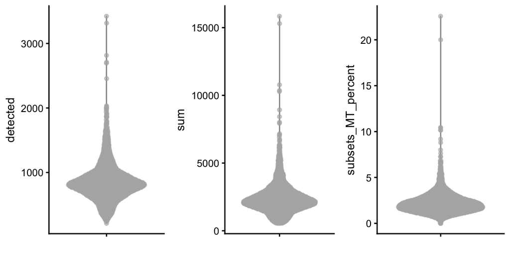

```r
library(LoomExperiment)
library(scater)
sce <- import('outputs/sce_after_qc.loom', format = "loom", type = "SingleCellLoomExperiment")
plot_list <- list()
plot_list[["detected"]] <- scater::plotColData(
    object = sce,
    y = "detected"
)
plot_list[["sum"]] <- scater::plotColData(
    object = sce,
    y = "sum"
)
plot_list[["subsets_MT_percent"]] <- scater::plotColData(
    object = sce,
    y = "subsets_MT_percent"
)
cowplot::plot_grid(plotlist = plot_list, nrow = 1)
```

```r
rm(list = ls())
```

The `plotColData()` function can also plot one QC metric on the y-axis against another QC metric on the x-axis. This can be additional insights into the relationship between QC metrics and help determine appropriate thresholds for filtering out low-quality cells.

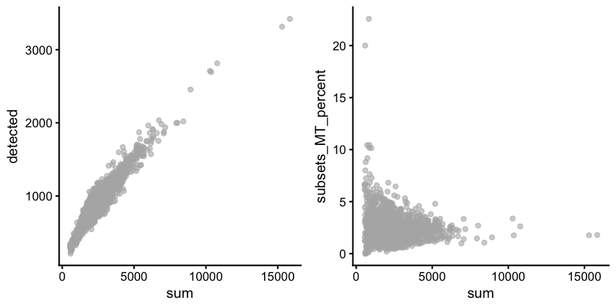

```r
library(LoomExperiment)
library(scater)
sce <- import('outputs/sce_after_qc.loom', format = "loom", type = "SingleCellLoomExperiment")
plot_list <- list()
plot_list[["detected"]] <- scater::plotColData(
    object = sce,
    y = "detected",
    x = "sum"
)
plot_list[["subsets_MT_percent"]] <- scater::plotColData(
    object = sce,
    y = "subsets_MT_percent",
    x = "sum"
)
cowplot::plot_grid(plotlist = plot_list, nrow = 1)
```

```r
rm(list = ls())
```

Notes:

- In contrast to the ‘violin plot’ use case above, where users can give a list of column names that the wrapper can simply loop over, this ‘scatter plot’ use case requires two features per plot - one of the y-axis and one for the x-axis - which immediately complicates the idea of producing multiple plots for multiple combinations of features on the X-Y axes.
- Again, taking inspiration from the [Seurat Visualize](https://usegalaxy.eu/?tool_id=toolshed.g2.bx.psu.edu%2Frepos%2Fiuc%2Fseurat_plot%2Fseurat_plot%2F5.4.0%2Bgalaxy2&version=latest), the tool should only allow users to specify one feature for the x-axis and one feature for the y-axis, forcing them to call `scater::plotColData()` once per combination of features on the X-Y axes.
- The code demonstrated above uses `cowplot::plot_grid()` to combine multiple plots into a single figure only for the purpose of producing an image to paste in the GTN tutorial. In a Galaxy workflow, the tool should produce one image per call to `scater::plotColData()` and not attempt to combine them into a single figure. {: .comment}

#### Filter Out Low Quality Cells

Having visualised the quality control metrics, we can now filter out low-quality cells based on thresholds for the number of detected genes and the percentage of mitochondrial reads.

```r
library(LoomExperiment)
sce <- import('outputs/sce_after_qc.loom', format = "loom", type = "SingleCellLoomExperiment")
keep_cells <- sce$detected >= 200 & sce$detected <= 2500 & sce$subsets_MT_percent <= 5
sce <- sce[, keep_cells]
if (!file.exists("outputs/sce_after_qc_filter.loom")) {
    export(object = sce, con = "outputs/sce_after_qc_filter.loom", format = "loom")
}
rm(sce)
```

Notes:

- Not every user will want to apply the same types of filters. Typically there are three metrics (total UMI, number of genes detected, mitochondrial content). For each metrics, users might choose to apply a lower cutoff and a higher cutoff. The Galaxy tool should offer the flexibility to filter on any of those six metrics. Take inspiration from the equivalent Seurat tool that already exists.

#### Visualise QC Metrics After Filtering

We can then produce the same plots as earlier to visualise the new distribution of quality control metrics in our data.

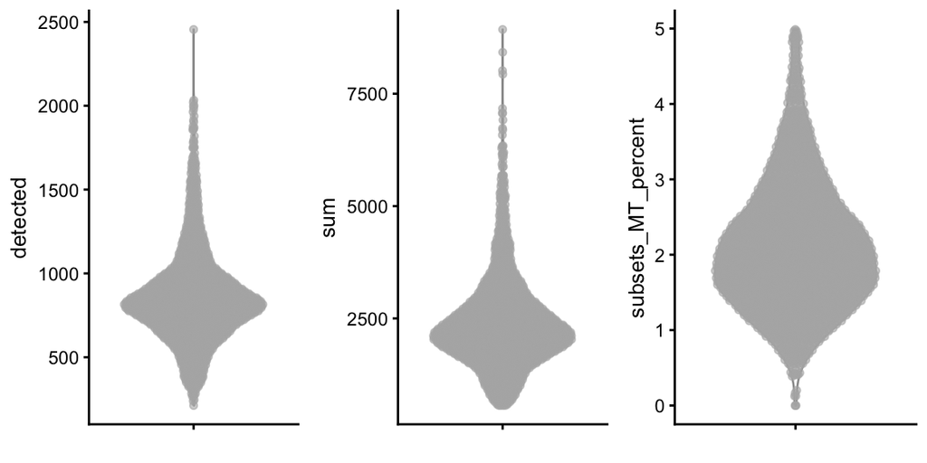

```r
library(LoomExperiment)
library(scater)
sce <- import('outputs/sce_after_qc_filter.loom', format = "loom", type = "SingleCellLoomExperiment")
plot_list <- list()
plot_list[["detected"]] <- scater::plotColData(
    object = sce,
    y = "detected"
)
plot_list[["sum"]] <- scater::plotColData(
    object = sce,
    y = "sum"
)
plot_list[["subsets_MT_percent"]] <- scater::plotColData(
    object = sce,
    y = "subsets_MT_percent"
)
cowplot::plot_grid(plotlist = plot_list, nrow = 1)
```

```r
rm(list = ls())
```

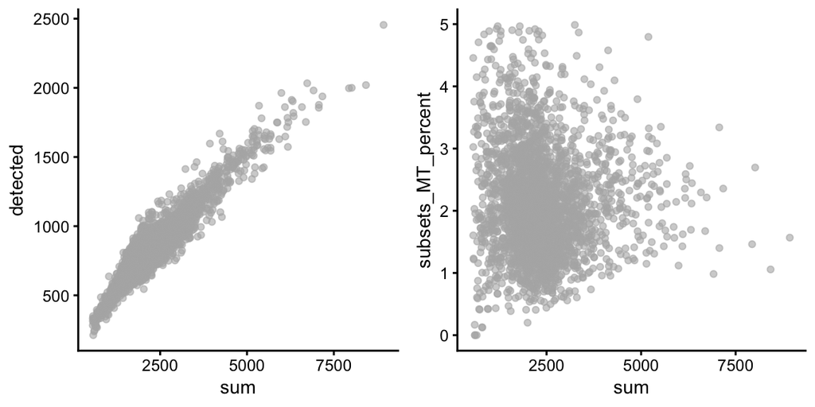

```r
library(LoomExperiment)
library(scater)
sce <- import('outputs/sce_after_qc_filter.loom', format = "loom", type = "SingleCellLoomExperiment")
plot_list <- list()
plot_list[["detected"]] <- scater::plotColData(
    object = sce,
    y = "detected",
    x = "sum"
)
plot_list[["subsets_MT_percent"]] <- scater::plotColData(
    object = sce,
    y = "subsets_MT_percent",
    x = "sum"
)
cowplot::plot_grid(plotlist = plot_list, nrow = 1)
```

```r
rm(list = ls())
```

### Further Preprocessing

#### Log-normalisation

Having filtered droplets that do not pass our chosen quality control filters, the next step in a standard single-cell RNA-sequencing analysis workflow is normalisation.

In Bioconductor, the simple log-normalisation method is implemented in the function `normalizeRnaCounts.se()` of the [scrapper](https://bioconductor.org/packages/scrapper/) package.

```r
library(LoomExperiment)
sce <- import('outputs/sce_after_qc_filter.loom', format = "loom", type = "SingleCellLoomExperiment")
sce <- scrapper::normalizeRnaCounts.se(x = sce)
```

```
using unknown matrix fallback for 'HDF5ArraySeed'
```

```r
dimnames(sce@assays@data$counts) <- list(NULL, NULL)
dimnames(sce@assays@data$logcounts) <- list(NULL, NULL)
if (!file.exists("outputs/sce_after_lognorm.loom")) {
    export(object = sce, con = "outputs/sce_after_lognorm.loom", format = "loom")
}
```

#### Model gene variance

We can then model gene variance using the matrix normalised of normalised counts using the `modelGeneVariances()` function of the [scrapper](https://bioconductor.org/packages/scrapper/) package.

```r
library(LoomExperiment)
sce <- import('outputs/sce_after_lognorm.loom', format = "loom", type = "SingleCellLoomExperiment")
allf <- scrapper::modelGeneVariances(x = logcounts(sce))
```

```
using unknown matrix fallback for 'HDF5ArraySeed'
```

```r
allf_df <- as.data.frame(allf$statistics)
allf_df <- data.frame(gene = rownames(allf_df), allf_df, row.names = NULL, check.names = FALSE)
write.table(
    allf_df, file = "outputs/scrapper_model_gene_var.tsv", sep = "\t",
    quote = FALSE, row.names = FALSE, col.names = TRUE
)
```

```r
hvgs <- scrapper::chooseHighlyVariableGenes(allf$statistics$residuals, top = 2000)
```

> TODO: check for existing Galaxy tool wrapper.

> Note: The wrapper should output both:
> - the table of statistics for later plotting, see below (tsv)
> - the identifiers of highly variable genes (txt)

```r
message("No direct equivalent to Seurat ScaleData")
```

```
No direct equivalent to Seurat ScaleData
```

> TODO: check when this might have an impact on the rest of the tutorial

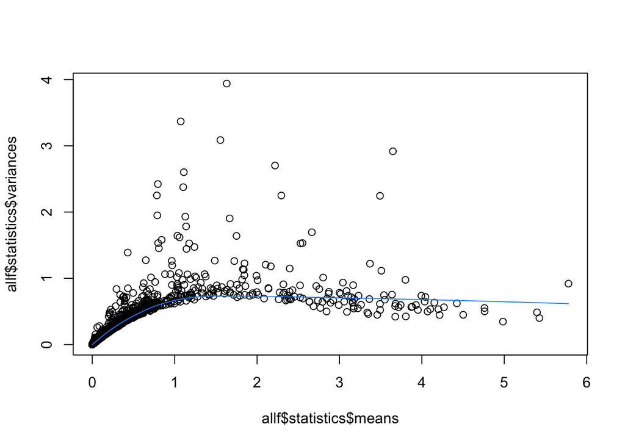

```r
plot(allf$statistics$means, allf$statistics$variances)
curve(approxfun(allf$statistics$means, allf$statistics$fitted)(x), add=TRUE, col="dodgerblue")
```

> TODO: check for existing Galaxy tool wrapper. Note that there is no packaged function available for this. Both the help page and the OSCA book give base R code for quick inspection. A Galaxy Tool wrapper could easily produce a nicer ggplot2 graphics including labels for the top N genes as in the Seurat tutorial.

## Dimensionality Reduction

### Principal Component Analysis

#### Perform the PCA

```r
sce <- scrapper::runPca.se(
    x = sce,
    features = hvgs,
    number = 50
)
```

```
using unknown matrix fallback for 'HDF5ArraySeed'
```

```r
sce
```

```
class: SingleCellLoomExperiment
dim: 32738 2638
metadata(6): CreatedWith LOOM_SPEC_VERSION ... Samples PCA
assays(2): counts logcounts
rownames(32738): MIR1302-10 FAM138A ... AC002321.2 AC002321.1
rowData names(3): ID Symbol subsets_MT
colnames: NULL
colData names(9): Barcode Sample ... sum total
reducedDimNames(1): PCA
mainExpName: NULL
altExpNames(0):
rowGraphs(0): NULL
colGraphs(0): NULL
```

> TODO: check for existing Galaxy tool wrapper.

### Visualise the PCA Results

#### Visualise the PCA Results - Dimensional Loadings

```r
message("No direct equivalent to Seurat::VizDimLoadings")
```

```
No direct equivalent to Seurat::VizDimLoadings
```

> Note: no direct impact on the rest of the tutorial.

#### Visualise the PCA Results - DimPlot

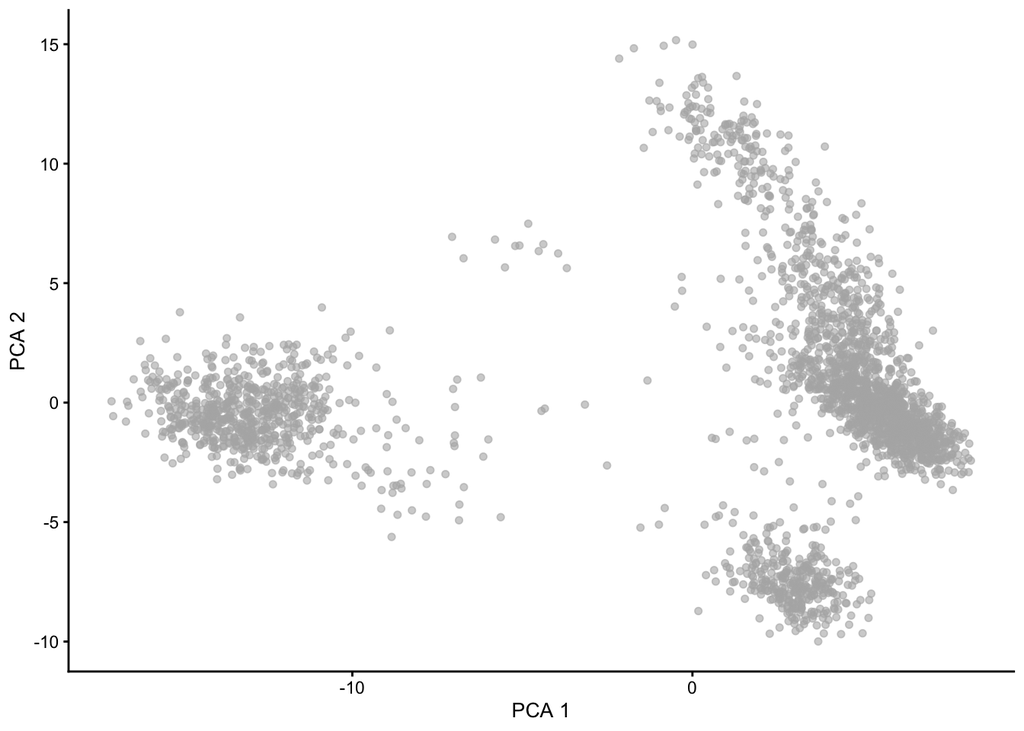

```r
scater::plotPCA(sce)
```

> TODO: check for existing Galaxy tool wrapper.

#### Visualise the PCA Results - Feature Plots

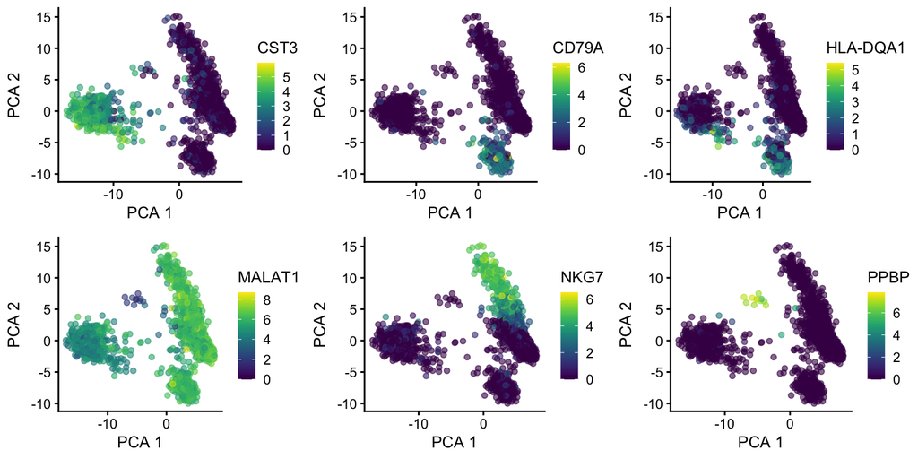

```r
plot_list <- list()
for (gene_id in c("CST3", "CD79A", "HLA-DQA1", "MALAT1", "NKG7", "PPBP")) {
    plot_list[[gene_id]] <- scater::plotPCA(
        object = sce,
        ncomponents = c(1, 2),
        colour_by = gene_id
    )
}
cowplot::plot_grid(plotlist = plot_list, nrow = 2)
```

> TODO: check for existing Galaxy tool wrapper.

Same for PC2 and PC3.

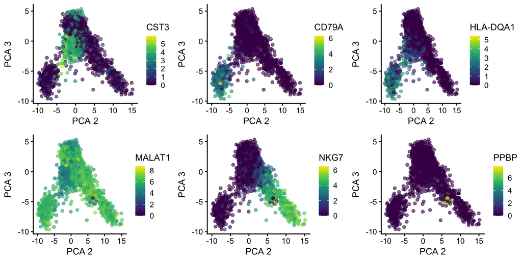

```r
plot_list <- list()
for (gene_id in c("CST3", "CD79A", "HLA-DQA1", "MALAT1", "NKG7", "PPBP")) {
    plot_list[[gene_id]] <- scater::plotPCA(
        object = sce,
        ncomponents = c(2, 3),
        colour_by = gene_id
    )
}
cowplot::plot_grid(plotlist = plot_list, nrow = 2)
```

> TODO: check for existing Galaxy tool wrapper.

> Note: this relies on the “uniquified gene symbol” rather than the actual gene symbol (available in `rowData(sce)[["Symbol"]]`). This ensures that every single feature in the dataset can be plotted whether or not it has a unique gene symbol or not.

#### Visualise the PCA Results - Heatmaps

```r
message("No direct equivalent to Seurat::DimHeatmap")
```

```
No direct equivalent to Seurat::DimHeatmap
```

> Note: no direct impact on the rest of the tutorial.

### Determine the ‘dimensionality’ of the dataset

#### Make an Elbow Plot

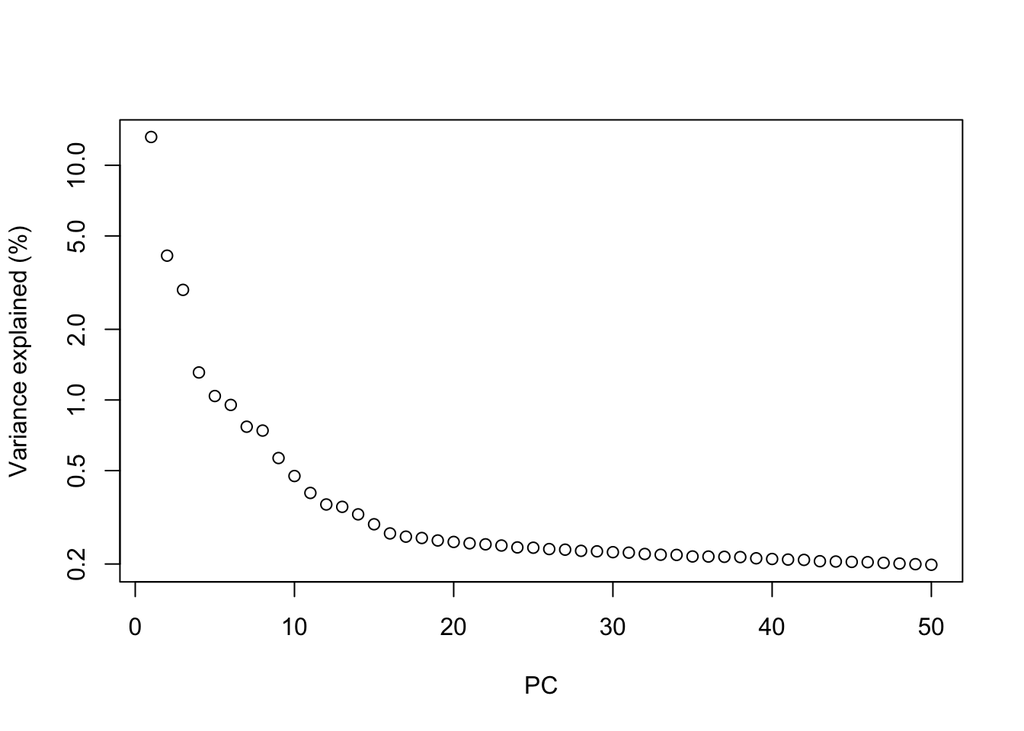

```r
percent.var <- 100 * metadata(sce)$PCA$variance.explained / metadata(sce)$PCA$total.variance
plot(percent.var, log="y", xlab="PC", ylab="Variance explained (%)")
```

> TODO: check for existing Galaxy tool wrapper.

## Cluster the Cells

```r
sce <- scrapper::clusterGraph.se(
    x = sce,
    num.neighbors = 10,
    method = "multilevel",
    resolution = 0.7,
    reddim.type = "PCA",
    output.name = "cluster"
)
sce
```

```
class: SingleCellLoomExperiment
dim: 32738 2638
metadata(6): CreatedWith LOOM_SPEC_VERSION ... Samples PCA
assays(2): counts logcounts
rownames(32738): MIR1302-10 FAM138A ... AC002321.2 AC002321.1
rowData names(3): ID Symbol subsets_MT
colnames: NULL
colData names(10): Barcode Sample ... total cluster
reducedDimNames(1): PCA
mainExpName: NULL
altExpNames(0):
rowGraphs(0): NULL
colGraphs(0): NULL
```

> TODO: check for existing Galaxy tool wrapper.

> Note: `num.neighbors`, `method`, and `resolution` are thrown in there to illustrate how this might be configured, but a lot customisation is possible.

### Run non-linear dimensional reduction (UMAP/tSNE)

#### Perform Dimensional Reduction with UMAP

```r
sce <- scrapper::runUmap.se(
    x = sce,
    reddim.type = "PCA"
)
sce
```

```
class: SingleCellLoomExperiment
dim: 32738 2638
metadata(6): CreatedWith LOOM_SPEC_VERSION ... Samples PCA
assays(2): counts logcounts
rownames(32738): MIR1302-10 FAM138A ... AC002321.2 AC002321.1
rowData names(3): ID Symbol subsets_MT
colnames: NULL
colData names(10): Barcode Sample ... total cluster
reducedDimNames(2): PCA UMAP
mainExpName: NULL
altExpNames(0):
rowGraphs(0): NULL
colGraphs(0): NULL
```

> TODO: check for existing Galaxy tool wrapper.

### Visualise UMAP

#### Visualise the UMAP

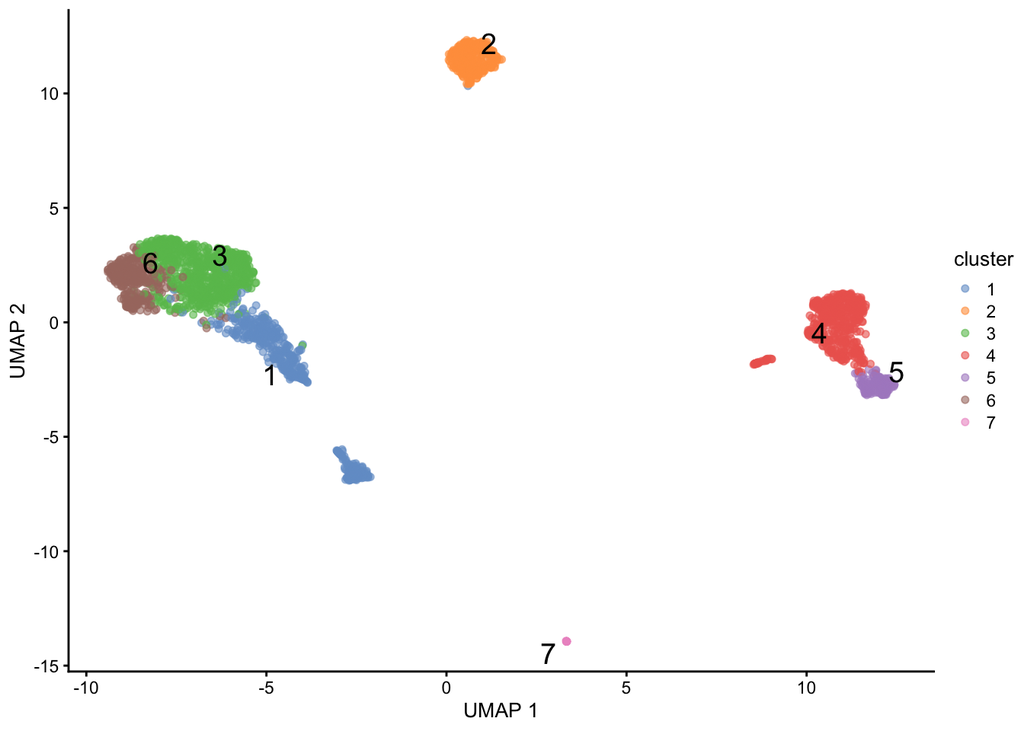

```r
scater::plotUMAP(
    object = sce,
    colour_by = "cluster",
    text_by = "cluster"
)
```

> TODO: check for existing Galaxy tool wrapper.

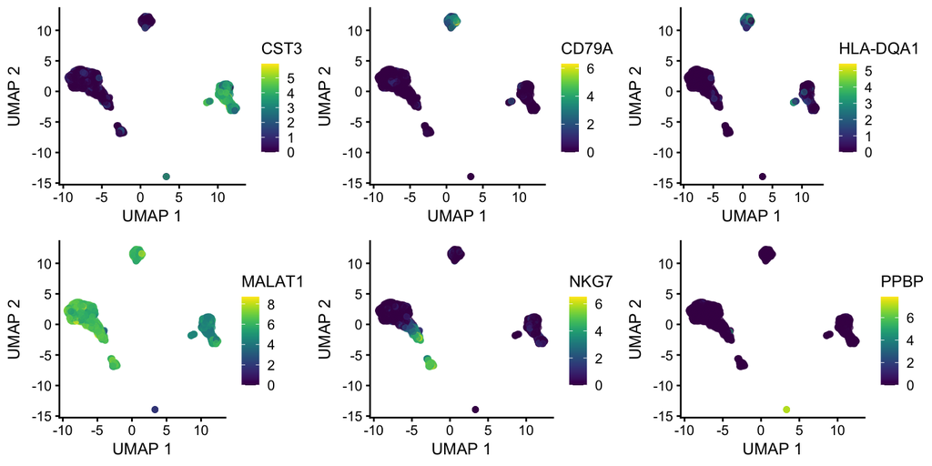

```r
plot_list <- list()
for (gene_id in c("CST3", "CD79A", "HLA-DQA1", "MALAT1", "NKG7", "PPBP")) {
    plot_list[[gene_id]] <- scater::plotUMAP(
        object = sce,
        colour_by = gene_id
    )
}
cowplot::plot_grid(plotlist = plot_list, nrow = 2)
```

> TODO: check for existing Galaxy tool wrapper.

### Other ways to visualise clusters

#### Visualise Expression across Clusters with a Violin Plot

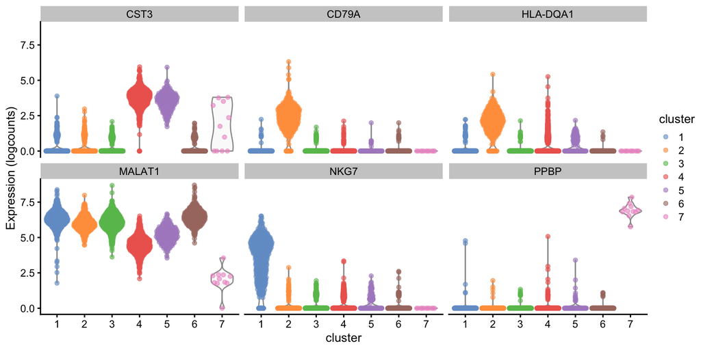

```r
plotExpression(
    object = sce,
    features = c("CST3", "CD79A", "HLA-DQA1", "MALAT1", "NKG7", "PPBP"),
    ncol = 3,
    x = "cluster",
    colour_by = "cluster"
)
```

> TODO: check for existing Galaxy tool wrapper.

## Find Marker Genes

### Find Positive Markers for Every Cluster Compared to the Rest

#### Use `scoreMarkers` to Compare All Clusters

```r
find_markers_results <- scrapper::scoreMarkers.se(
    x = sce,
    groups = colData(sce)[["cluster"]]
)
```

```
using unknown matrix fallback for 'HDF5ArraySeed'
```

```r
find_markers_results
```

```
List of length 7
names(7): 1 2 3 4 5 6 7
```

> TODO: check for existing Galaxy tool wrapper.

> Note: This function produces a Bioconductor `List` of tables (one per cluster) which would need to be saved in an RDS file unlike the combined table produced by Seurat where a column specifies the cluster for which each gene is a marker of. Furthermore, in the present case, there is no easy way to combine that list of tables into a single table because they have different sets of column headers (each cluster isn’t tested against itself).

### Find Markers of Cluster 2

#### Use `FindMarkers` on a Single Cluster

```r
find_markers_results[["2"]]
```

```
DataFrame with 32738 rows and 22 columns
               mean   detected cohens.d.min cohens.d.mean cohens.d.median
          <numeric>  <numeric>    <numeric>     <numeric>       <numeric>
HLA-DRA     4.42219   1.000000      1.37256       4.42375         4.69516
CD74        5.08066   1.000000      2.09145       4.38294         4.63248
CD79A       2.30449   0.930636      3.11905       3.17222         3.15268
HLA-DPB1    3.15602   0.985549      1.10373       3.10994         3.61139
HLA-DRB1    2.80880   0.982659      0.77001       2.88153         3.54188
...             ...        ...          ...           ...             ...
CCL5     0.17591231 0.14161850    -10.13360      -2.18891      -0.1257892
GNG11    0.00356461 0.00289017    -13.36384      -2.29182      -0.1150258
S100A4   0.52325300 0.36127168     -5.21584      -2.38239      -1.9818641
PF4      0.01379371 0.01445087    -18.06456      -3.01750      -0.0612898
PPBP     0.01912297 0.01445087    -17.76688      -3.02455      -0.0998548
         cohens.d.max cohens.d.min.rank     auc.min  auc.mean auc.median
            <numeric>         <integer>   <numeric> <numeric>  <numeric>
HLA-DRA       6.78045                 1    0.843265  0.965506   0.996376
CD74          6.12898                 2    0.939530  0.986286   0.997994
CD79A         3.28284                 1    0.961484  0.962812   0.962476
HLA-DPB1      4.36875                 3    0.779087  0.935000   0.979751
HLA-DRB1      4.41060                 3    0.707269  0.900758   0.977547
...               ...               ...         ...       ...        ...
CCL5        0.0611804             32738 0.000000000  0.336614   0.476951
GNG11       0.0760286             32738 0.000000000  0.410686   0.494196
S100A4      0.1531925             32738 0.000597303  0.194980   0.106408
PF4         0.1651851             32738 0.000000000  0.416131   0.499001
PPBP        0.0405773             32738 0.000000000  0.408432   0.490138
           auc.max auc.min.rank delta.mean.min delta.mean.mean
         <numeric>    <integer>      <numeric>       <numeric>
HLA-DRA   0.999373            1       1.396072         3.14069
CD74      1.000000            1       1.943944         3.24710
CD79A     0.965318            2       2.252555         2.26943
HLA-DPB1  0.989913            3       1.229930         2.30935
HLA-DRB1  0.988530            4       0.776415         1.98740
...            ...          ...            ...             ...
CCL5      0.508145        32738       -4.34743       -1.227575
GNG11     0.501445        32738       -4.79236       -0.810129
S100A4    0.565029        32738       -3.60717       -1.808720
PF4       0.507225        32738       -5.43022       -0.911309
PPBP      0.502283        32738       -6.89580       -1.168661
```

[output cut: 24 more lines]

```
PF4               -0.985549           -0.165291            -0.0019330
PPBP              -0.985549           -0.180863            -0.0198845
         delta.detected.max delta.detected.min.rank
                  <numeric>               <integer>
HLA-DRA            0.721591                       7
CD74               0.363636                      29
CD79A              0.930636                       1
HLA-DPB1           0.894640                       9
HLA-DRB1           0.891750                       1
...                     ...                     ...
CCL5             0.01661850                   32738
GNG11            0.00289017                   32738
S100A4           0.17945349                   32738
PF4              0.01445087                   32738
PPBP             0.00462768                   32738
```

> TODO: check for existing Galaxy tool wrapper.

> Note: For this one, simply extract the second element of the list produced in the previous step.

[… skipped over a few variations for marker detection …]

## Identify Cell Types

#### Make Violin Plots of B Cell Markers

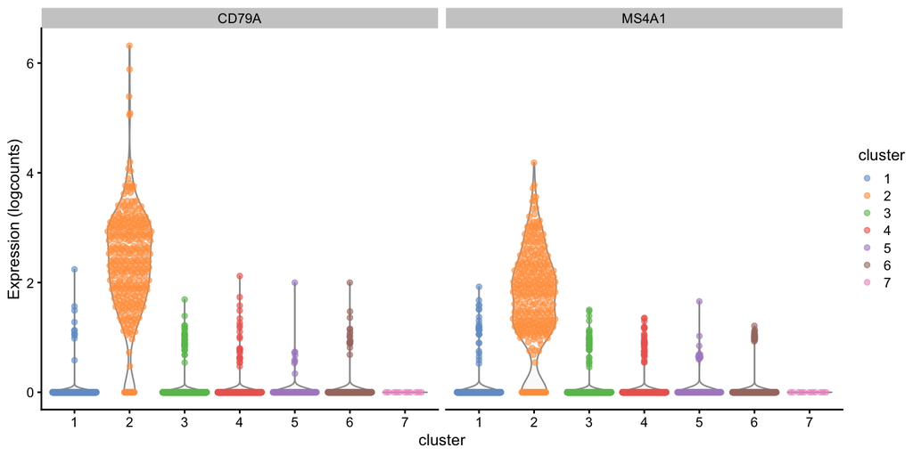

```r
plotExpression(
    object = sce,
    features = c("CD79A", "MS4A1"),
    ncol = 2,
    x = "cluster",
    colour_by = "cluster"
)
```

> TODO: check for existing Galaxy tool wrapper.

#### Make Violin Plots of T Cell Markers

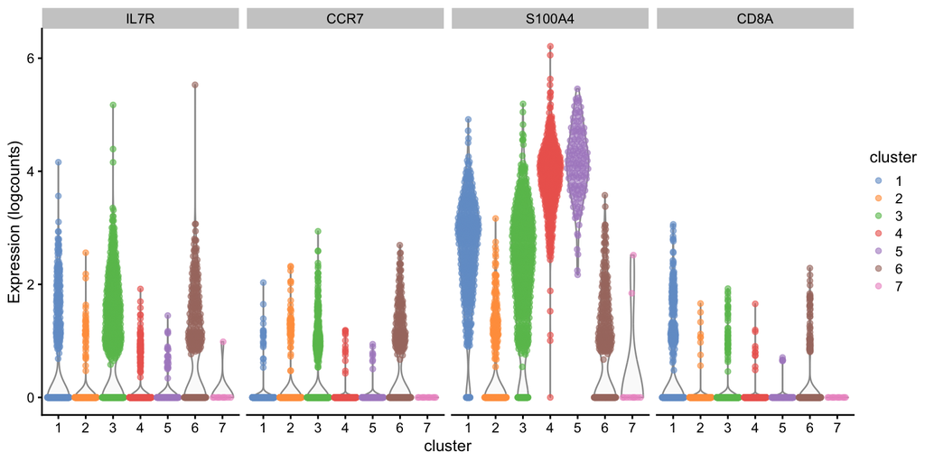

```r
plotExpression(
    object = sce,
    features = c("IL7R", "CCR7", "S100A4", "CD8A"),
    ncol = 4,
    x = "cluster",
    colour_by = "cluster"
)
```

> TODO: check for existing Galaxy tool wrapper.

#### Colour the UMAP Plot by Canonical Marker Expression

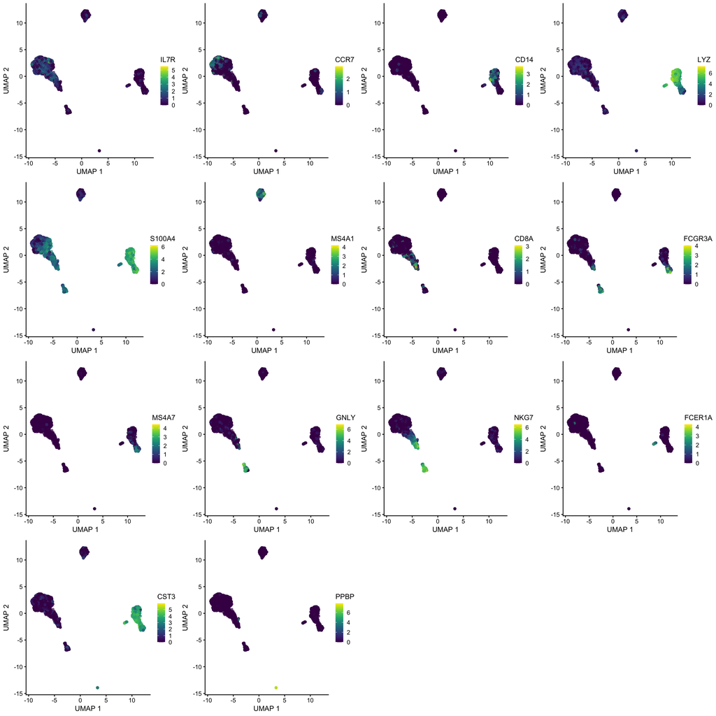

```r
gene_ids <- c(
    "IL7R", "CCR7", "CD14", "LYZ", "S100A4", "MS4A1", "CD8A", "FCGR3A", "MS4A7",
    "GNLY", "NKG7", "FCER1A", "CST3", "PPBP"
)
plot_list <- list()
for (gene_id in gene_ids) {
    plot_list[[gene_id]] <- scater::plotUMAP(
        object = sce,
        colour_by = gene_id
    )
}
cowplot::plot_grid(plotlist = plot_list, nrow = 4)
```

> TODO: check for existing Galaxy tool wrapper.